# Assignment Practical Machine Learning

HM Schaink

March 7th, 2019

## Introduction

This project deals with research on Human Activity Recognition. The aim of this project is to predict the type of activity that is done by a test person on basis of measurements performed by wearable accelleometers on the belt, forearm, arm, and dumbbell. The data is collected using 6 test persons, who performed 5 different activities: sitting, sitting down, standing up, standing, walking.

The data used in this project is obtained from: http://groupware.les.inf.puc-rio.br/har On this website more information about this experiment can be found.

This project is done in partial fulfilment of the Coursera course ‘Practical machine learning’.

```r
  library(graphics); library(ggplot2); library(caret); library(dplyr); library(knitr)
```

The data is read initially as character variables, in order to prevent format errors later on in the code. The data is later converted to numericals in order to be able to perform the calculations. The dimension of the training set is equal to

```r
  trainingSet<-read.csv("pml-training.csv",colClasses="character")
  print(dim(trainingSet))
```

```
## [1] 19622   160
```

The dimension of the testing set is equal to

```r
  testingSet<-read.csv("pml-testing2.csv",colClasses="character")
  print(dim(testingSet))
```

```
## [1]  20 160
```

It is clear that the training set is sufficiently large to separate it into a new training set and a validation set. The new training set will be used to develop the machine learning algorithm, the validation set is used to optimize the model. These sets are created next. The diemnsions ot these sets are

```r
  set.seed(13234)
  inTrain<-createDataPartition(y=trainingSet$classe,p=0.7,list=FALSE)
  trainingSet2<-trainingSet[inTrain,]
  print(dim(trainingSet2))
```

```
## [1] 13737   160
```

```r
  validation2<-trainingSet[-inTrain,]
  print(dim(validation2))
```

```
## [1] 5885  160
```

## Exploration and reduction of the data

A first impression of the data is obtained using the tests

```r
print(head(trainingSet2))
print(str(trainingSet2))
```

[output not shown]

From these tests it can be learned that:

1. The first columns contain information about the number of the experiment, the test-person, the time and duration of the experiments etc. This information can be omitted from the calculation
2. The measurement data are presented in columns 9-159
3. The last column (classe) contains information about the specific exercise, which are labeled by the factors A, B, C, D, E. The machine learning algorithm should be able to predict these values on basis of the experimental results.
4. Several columns have titles that start with “stddev”. Apparently these columns contain information about the standard deviations of the experiments. It would be unwise to give the data in these columns the same numerical treatment as the actual experimental values. For this reason these columns will be omited from the analysis.

### Reducing and reformatting the data set

```r
newData<-function(DataSet) {
  number_of_columns<-ncol(DataSet)
  columnNames<-colnames(DataSet)
  trainClass<-select(DataSet,columnNames[number_of_columns])

  istart<-8
  iend<-number_of_columns-1
  dd<-select(DataSet,istart:iend)
  newTrain<-sapply(dd,as.numeric)

## ########## The classe column is attached to the data ############
  newTrain<-cbind(newTrain,trainClass)
}
```

Applying this function to the training set yields a data set with the dimension

```r
trainingSet3<-newData(trainingSet2)
```

```r
print(dim(trainingSet3))
```

```
## [1] 13737   153
```

Next, the columns refering to the standard deviations are removed from the dataset (see point 4. above).

```r
newTrain<-trainingSet3
selectTrain<-select(newTrain,-starts_with("stddev"))
print(dim(selectTrain))
```

```
## [1] 13737   141
```

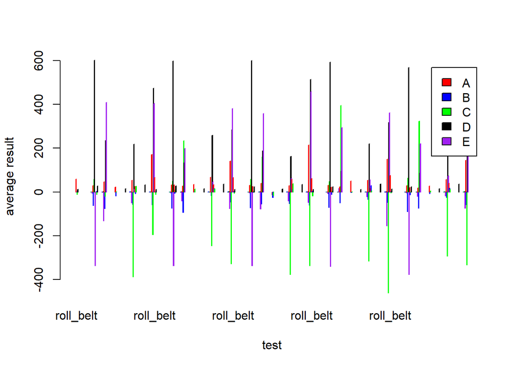

```r
dataClassA<-filter(selectTrain,as.character(classe)=="A")
dataClassA_mean<-sapply(dataClassA[,-141],mean,na.rm=FALSE)

dataClassB<-filter(selectTrain,as.character(classe)=="B")
dataClassB_mean<-sapply(dataClassB[,-141],mean,na.rm=FALSE)

dataClassC<-filter(selectTrain,as.character(classe)=="C")
dataClassC_mean<-sapply(dataClassC[,-141],mean,na.rm=FALSE)

dataClassD<-filter(selectTrain,as.character(classe)=="D")
dataClassD_mean<-sapply(dataClassD[,-141],mean,na.rm=FALSE)

dataClassE<-filter(selectTrain,as.character(classe)=="E")
dataClassE_mean<-sapply(dataClassE[,-141],mean,na.rm=FALSE)

barplot(c(dataClassA_mean,dataClassB_mean,dataClassC_mean,dataClassD_mean,dataClassE_mean),
        col=c("red","blue","green","black","purple"),
        border=c("red","blue","green","black","purple"),beside=TRUE,
        legend.tex=c("A","B","C","D","E"),
        xlab="test",ylab="average result")
```

From the exploratory plot it can be seen that only a limited number of detectors contribute to the measured muscle-activity. Furthermore, the plot shows that it should be possible to use this dataset, to distinguish between the different exercises A. B, C, D, E.

```r
selectTrain[is.na(selectTrain)]<-0

nzv<-nearZeroVar(selectTrain,saveMetrics=TRUE)

nzvNames<-row.names(nzv)
numberOfRows<-nrow(nzv)

rNumber<-c(1:numberOfRows)
nzv<-cbind(nzv,rNumber)
nzv<-cbind(nzv,nzvNames)

nzvTT<-filter(nzv,(zeroVar==TRUE&nzv==TRUE))

nzvNamesTT<-(select(nzvTT,nzvNames))
nzvNumbers<-select(nzvTT,rNumber)
numberOfNZV<-nrow(nzvNumbers)

selectTrain_names<-names(selectTrain)
NZV_variables<-selectTrain_names[rNumber[1:numberOfNZV]]
selectTrain_2<-select(selectTrain,-NZV_variables)

print(NZV_variables)
```

```
## [1] "roll_belt"            "pitch_belt"           "yaw_belt"
## [4] "total_accel_belt"     "kurtosis_roll_belt"   "kurtosis_picth_belt"
## [7] "kurtosis_yaw_belt"    "skewness_roll_belt"   "skewness_roll_belt.1"
```

Furthermore, it is possible to omit the variables that contain only NA-values (which were set to zero in the previous block of code. These variables are

```r
numberOfRows<-nrow(selectTrain_2)
colAllNa<-colSums(selectTrain_2==0)
allNa<-colAllNa[colAllNa==numberOfRows]
allNa_names<-names(allNa)
selectTrain_3<-select(selectTrain_2,-allNa_names)
print(allNa_names)
```

```
## [1] "skewness_yaw_belt"      "amplitude_yaw_belt"
## [3] "kurtosis_yaw_dumbbell"  "skewness_yaw_dumbbell"
## [5] "amplitude_yaw_dumbbell" "kurtosis_yaw_forearm"
## [7] "skewness_yaw_forearm"   "amplitude_yaw_forearm"
```

It is rather surprising that the last reduction finds variables that were not detected by the near zero value approach…

The steps performed above have reduced the dimension of the data set to

```r
print(dim(selectTrain_3))
```

```
## [1] 13737   124
```

In view of the exploration plot given above, it should be possible to reduce that data-set even further. However, at this point it is decided to start developing the model.

## Training the models

```r
## modFit1<-train(as.factor(classe)~. ,data=selectTrain_3,method="rpart")
## print((modFit1)
```

The second method tried is a bagging method. It needs about 10 minutes to complete when the default setting for the cross-validations (25) is used. However, the accuracy is found to be very high (0,964). In order to reduce the calculation-time, the number of cross-validations was set to 5. This did not affect the accuracy seriously.

```r
trcntrl<-trainControl(method="cv",number=5)
modFit2<-train(classe~. ,data=selectTrain_3,method="treebag",trControl=trcntrl)
print((modFit2))
```

```
## Bagged CART
##
## 13737 samples
##   123 predictor
##     5 classes: 'A', 'B', 'C', 'D', 'E'
##
## No pre-processing
## Resampling: Cross-Validated (5 fold)
## Summary of sample sizes: 10989, 10990, 10989, 10991, 10989
## Resampling results:
##
##   Accuracy   Kappa
##   0.9714639  0.9638905
```

Boosting using the method gbm and the random forest methods were also tested and were found to be very time consuming and were stopped before the end of the run.

## Validation of the method

First the validation data should be reduced using the same pre-processing steps as applied to the training data, using the results obtained in the trainng step. This is done in the steps below:

```r
validation3<-newData(validation2)
validation3<-select(validation3,-starts_with("stddev"))
validation3[is.na(validation3)]<-0
validation3<-select(validation3,-NZV_variables)
validation3<-select(validation3,-allNa_names)
print(dim(validation3))
```

```
## [1] 5885  124
```

The validation of te bagging with trees model bagging with trees yield the following confusion matrix:

```r
val<-predict(modFit2,newdata=validation3,na.action=na.pass)
print(confusionMatrix(val,as.factor(validation3$classe)))
```

```
## Confusion Matrix and Statistics
##
##           Reference
## Prediction    A    B    C    D    E
##          A 1661   16    1    2    4
##          B    5 1094   20    3    6
##          C    5   19  984   33    5
##          D    1    7   18  917    1
##          E    2    3    3    9 1066
##
## Overall Statistics
##
##                Accuracy : 0.9723
##                  95% CI : (0.9678, 0.9763)
##     No Information Rate : 0.2845
##     P-Value [Acc > NIR] : < 2.2e-16
##
##                   Kappa : 0.965
##  Mcnemar's Test P-Value : 0.009473
##
## Statistics by Class:
##
##                      Class: A Class: B Class: C Class: D Class: E
## Sensitivity            0.9922   0.9605   0.9591   0.9512   0.9852
## Specificity            0.9945   0.9928   0.9872   0.9945   0.9965
## Pos Pred Value         0.9863   0.9699   0.9407   0.9714   0.9843
## Neg Pred Value         0.9969   0.9905   0.9913   0.9905   0.9967
## Prevalence             0.2845   0.1935   0.1743   0.1638   0.1839
## Detection Rate         0.2822   0.1859   0.1672   0.1558   0.1811
## Detection Prevalence   0.2862   0.1917   0.1777   0.1604   0.1840
## Balanced Accuracy      0.9934   0.9767   0.9732   0.9729   0.9908
```

It is clear that the bagging with trees method performs very well.

## Testing of the method

Now the bagging method is used to predict the classe of activities in the test data. As in the validation step, it is necessary that the test data should be pre-process on a similar manner as the training data, using the results obtaining in the training step. These steps are described in detail in the description of the validation.

```r
test3<-newData(testingSet)
test3<-select(test3,-starts_with("stddev"))
test3[is.na(test3)]<-0
test3<-select(test3,-NZV_variables)
test3<-select(test3,-allNa_names)
print(dim(test3))
```

```
## [1]  20 124
```

The resulting predictions for the test data are:

```r
val_2<-predict(modFit2,newdata=test3,na.action=na.pass)
print(val_2)
```

```
##  [1] B A B A A E D B A A B C B A E E A B B B
## Levels: A B C D E
```